#### **Set working Directory**

```r
setwd("C:\\Users\\VB\\Desktop\\PROJECTS")
```

#### **Read Data**

```r
LungCapData <- read.csv("LungCapData.txt",header = T,sep = "\t")
```

```r
attach(LungCapData)
```

# **Data Exploring**

```r
str(LungCapData)
```

```
## 'data.frame':    725 obs. of  6 variables:
##  $ LungCap  : num  6.47 10.12 9.55 11.12 4.8 ...
##  $ Age      : int  6 18 16 14 5 11 8 11 15 11 ...
##  $ Height   : num  62.1 74.7 69.7 71 56.9 58.7 63.3 70.4 70.5 59.2 ...
##  $ Smoke    : Factor w/ 2 levels "no","yes": 1 2 1 1 1 1 1 1 1 1 ...
##  $ Gender   : Factor w/ 2 levels "female","male": 2 1 1 2 2 1 2 2 2 2 ...
##  $ Caesarean: Factor w/ 2 levels "no","yes": 1 1 2 1 1 1 2 1 1 1 ...
```

```r
dim(LungCapData)
```

```
## [1] 725   6
```

```r
length(LungCapData)
```

```
## [1] 6
```

```r
head(LungCapData)
```

```
##   LungCap Age Height Smoke Gender Caesarean
## 1   6.475   6   62.1    no   male        no
## 2  10.125  18   74.7   yes female        no
## 3   9.550  16   69.7    no female       yes
## 4  11.125  14   71.0    no   male        no
## 5   4.800   5   56.9    no   male        no
## 6   6.225  11   58.7    no female        no
```

```r
tail(LungCapData)
```

```
##     LungCap Age Height Smoke Gender Caesarean
## 720   7.325   9   66.3    no   male        no
## 721   5.725   9   56.0    no female        no
## 722   9.050  18   72.0   yes   male       yes
## 723   3.850  11   60.5   yes female        no
## 724   9.825  15   64.9    no female        no
## 725   7.100  10   67.7    no   male        no
```

```r
names(LungCapData)
```

```
## [1] "LungCap"   "Age"       "Height"    "Smoke"     "Gender"    "Caesarean"
```

```r
levels(LungCapData$Smoke)
```

```
## [1] "no"  "yes"
```

```r
class(LungCapData$LungCap)
```

```
## [1] "numeric"
```

# **Data Cleaning**

##### **TRAILING AND LEADING SPACES**

```r
LungCapData$Smoke <- trimws(LungCapData$Smoke,which = c("right"))
LungCapData$Smoke <- trimws(LungCapData$Smoke,which = c("left"))
```

##### **HANDLING PUNCTUATION MARKS**

```r
LungCapData$smoke <- gsub("[[:punct:]]|[[:digit:]]|(http[[:alpha:]]*:\\/\\/)","",LungCapData$Smoke)
```

##### **IDENTIFYING MISSING VALUES**

```r
library(mice)
library(VIM)
```

[output not shown]

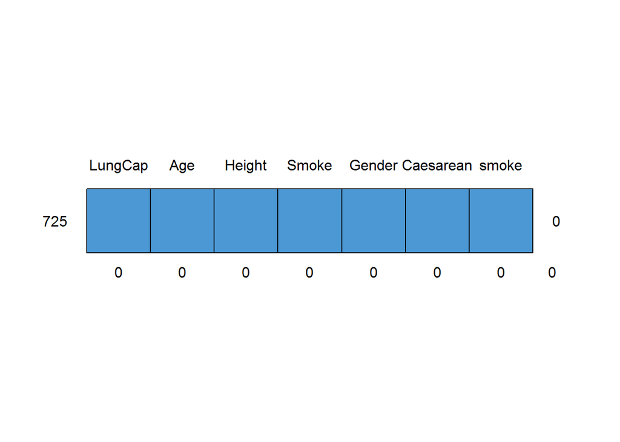

```
##     LungCap Age Height Smoke Gender Caesarean smoke
## 725       1   1      1     1      1         1     1 0
##           0   0      0     0      0         0     0 0
```

```r
md.pattern(LungCapData)
```

```r
md.pairs(LungCapData)
```

```
## $rr
##           LungCap Age Height Smoke Gender Caesarean smoke
## LungCap       725 725    725   725    725       725   725
## Age           725 725    725   725    725       725   725
## Height        725 725    725   725    725       725   725
## Smoke         725 725    725   725    725       725   725
## Gender        725 725    725   725    725       725   725
## Caesarean     725 725    725   725    725       725   725
## smoke         725 725    725   725    725       725   725
##
## $rm
##           LungCap Age Height Smoke Gender Caesarean smoke
## LungCap         0   0      0     0      0         0     0
## Age             0   0      0     0      0         0     0
## Height          0   0      0     0      0         0     0
## Smoke           0   0      0     0      0         0     0
## Gender          0   0      0     0      0         0     0
## Caesarean       0   0      0     0      0         0     0
## smoke           0   0      0     0      0         0     0
##
## $mr
##           LungCap Age Height Smoke Gender Caesarean smoke
## LungCap         0   0      0     0      0         0     0
## Age             0   0      0     0      0         0     0
## Height          0   0      0     0      0         0     0
## Smoke           0   0      0     0      0         0     0
## Gender          0   0      0     0      0         0     0
## Caesarean       0   0      0     0      0         0     0
## smoke           0   0      0     0      0         0     0
##
## $mm
##           LungCap Age Height Smoke Gender Caesarean smoke
## LungCap         0   0      0     0      0         0     0
## Age             0   0      0     0      0         0     0
## Height          0   0      0     0      0         0     0
## Smoke           0   0      0     0      0         0     0
## Gender          0   0      0     0      0         0     0
## Caesarean       0   0      0     0      0         0     0
## smoke           0   0      0     0      0         0     0
```

```r
p <- function(x){sum(is.na(x))/length(x)*100}
apply(LungCapData,2,p)
```

```
##   LungCap       Age    Height     Smoke    Gender Caesarean     smoke
##         0         0         0         0         0         0         0
```

```r
apply(is.na(LungCapData),2,which)
```

```
## integer(0)
```

# **Exploratory Data Analysis**

#### **UNIVARITE ANALYSIS-** *to check the summary of the data to get rough idea about Data.*

```r
summary(LungCapData)
```

```
##     LungCap            Age            Height         Smoke
##  Min.   : 0.507   Min.   : 3.00   Min.   :45.30   Length:725
##  1st Qu.: 6.150   1st Qu.: 9.00   1st Qu.:59.90   Class :character
##  Median : 8.000   Median :13.00   Median :65.40   Mode  :character
##  Mean   : 7.863   Mean   :12.33   Mean   :64.84
##  3rd Qu.: 9.800   3rd Qu.:15.00   3rd Qu.:70.30
##  Max.   :14.675   Max.   :19.00   Max.   :81.80
##     Gender    Caesarean    smoke
##  female:358   no :561   Length:725
##  male  :367   yes:164   Class :character
##                         Mode  :character
##
##
##
```

# **Frequency Distribution**

#### *to examine the outliers and significant trends are the relative abundance of each particular target data within dataset.*

```r
breaks <- seq(from=min(Age),to=max(Age),by=3)
pop <- cut(Age,breaks = breaks,right = TRUE,include.lowest = FALSE)
title <- (cbind(table(pop)))
colnames(title) <- c("frequency");title
```

```
##         frequency
## (3,6]          51
## (6,9]         118
## (9,12]        177
## (12,15]       189
## (15,18]       140
```

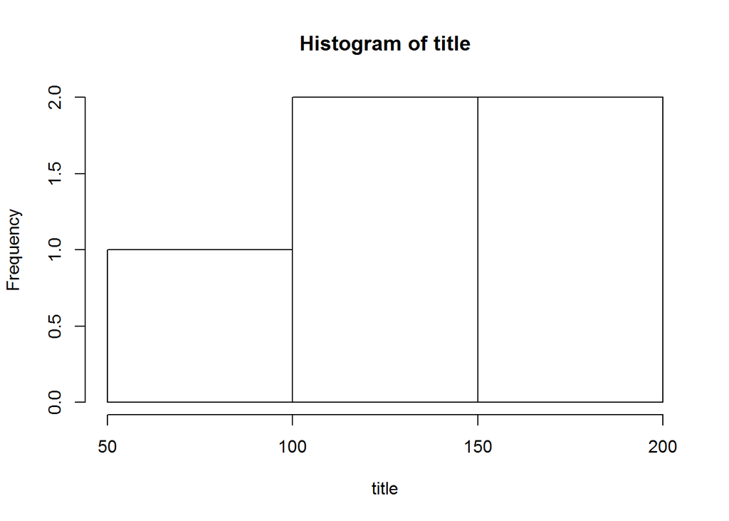

```r
hist(title)
```

#### **Table for proportion -** *to examine the number of observations for a variables.*

```r
table(Smoke)
```

```
## Smoke
##  no yes
## 648  77
```

```r
table(Smoke)/length(Smoke)
```

```
## Smoke
##        no       yes
## 0.8937931 0.1062069
```

#### **Create two way table or contigency table**

```r
table(Smoke,Gender)
```

```
##      Gender
## Smoke female male
##   no     314  334
##   yes     44   33
```

# **Measures of Central Tendency**

##### **Calculate the count of variable which is going to analyze**

```r
length(LungCap)
```

```
## [1] 725
```

##### **Calcualte the Sum of the LungCap**

```r
sum(LungCap)
```

```
## [1] 5700.782
```

##### **Calculate the Mean of LungCap**

```r
mean(LungCap)
```

```
## [1] 7.863148
```

##### **Calculate the Median of of Luncap**

```r
median(LungCap)
```

```
## [1] 8
```

##### **Calculate the Mode of Luncap**

```r
mode <- function(x){
  ux <- unique(x)
  ux[which.max(tabulate(match(x,ux)))]
}
```

```r
mode(LungCap)
```

```
## [1] 8.35
```

# **Measures of Dispersions**

##### **Calculate the Range of the LungCap**

```r
range(LungCap)
```

```
## [1]  0.507 14.675
```

##### **Calculate quantile of the LungCap**

```r
quantile(LungCap)
```

```
##     0%    25%    50%    75%   100%
##  0.507  6.150  8.000  9.800 14.675
```

##### **Calculate IQR of the LungCap**

```r
IQR(LungCap)
```

```
## [1] 3.65
```

##### **Calculate min**

```r
min(LungCap)
```

```
## [1] 0.507
```

##### **Calculate Max**

```r
max(LungCap)
```

```
## [1] 14.675
```

##### **Calculate Variance**

```r
var(LungCap)
```

```
## [1] 7.086288
```

##### **Calculate Standard Deviation**

```r
sd(LungCap)
```

```
## [1] 2.662008
```

##### **Calculate Square root**

```r
sqrt(var(LungCap))
```

```
## [1] 2.662008
```

##### **calculate probabilities**

```r
quantile(LungCap,probs = c(0.20,0.5,0.9,1))
```

```
##    20%    50%    90%   100%
##  5.645  8.000 11.205 14.675
```

# **Measures of Shapes**

#### **Measures of Shapes -** *Describe the distribution of the data within dataset.*

##### **Calculate the Skewness**

```r
library(e1071)
skewness(LungCap)
```

```
## [1] -0.2269314
```

##### **Shapiro test is used to check normality.**

```r
shapiro.test(LungCap)
```

```
##
##  Shapiro-Wilk normality test
##
## data:  LungCap
## W = 0.99305, p-value = 0.001886
```

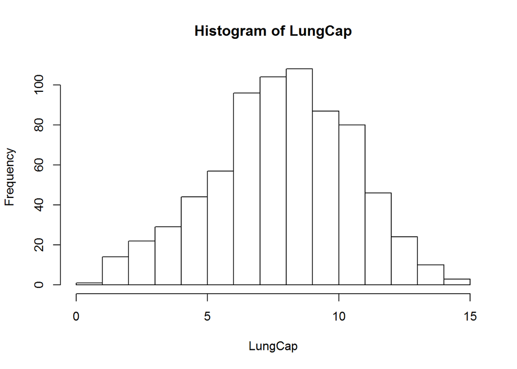

```r
hist(LungCap)
```

##### **Calculate the Kurtosis**

```r
kurtosis(LungCap)
```

```
## [1] -0.3259122
```

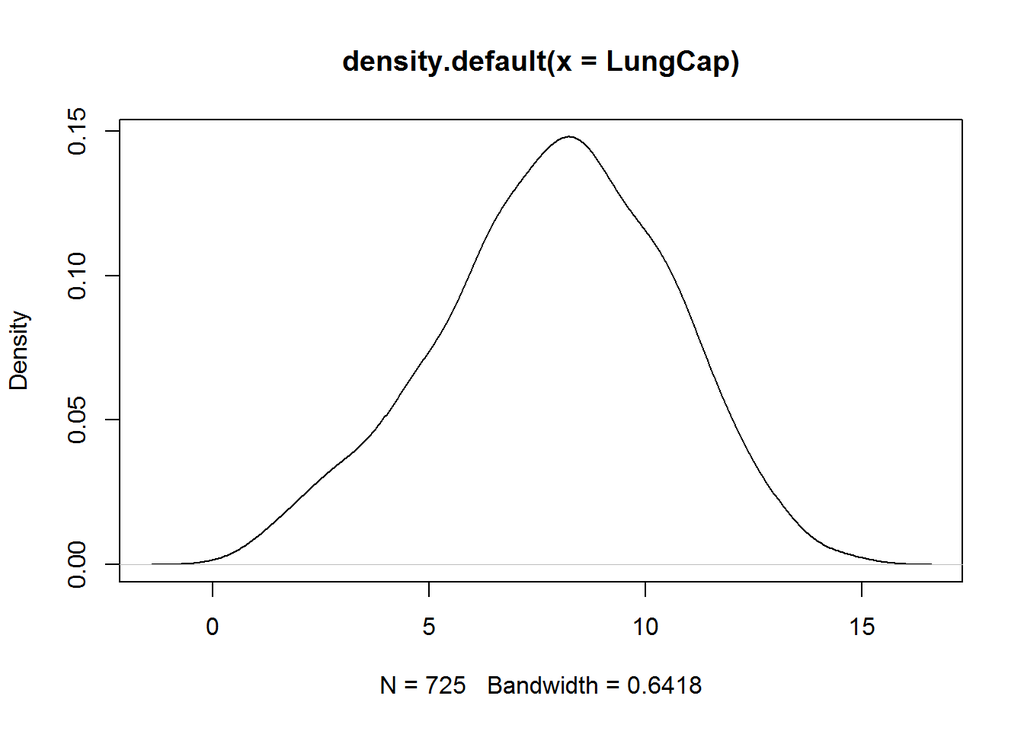

```r
plot(density(LungCap))
```

# **BIVARIATE ANALYSIS**

#### *Bivariate Analysis Deals with two sets of data. this paired data come from related sources or samples.*

##### **Correlation -** *is a parametric measure of the linear association between 2 numeric variables.*

```r
cor(LungCap,Height)
```

```
## [1] 0.9121873
```

```r
cor(LungCap,Age)
```

```
## [1] 0.8196749
```

##### **Covariance -** *measure of how much two random variables vary together.*

```r
cov(LungCap,Age)/(sd(LungCap)*sd(Age))
```

```
## [1] 0.8196749
```

##### **Calculating Corrlation matrix**

```r
cor(LungCapData[,1:3])
```

```
##           LungCap       Age    Height
## LungCap 1.0000000 0.8196749 0.9121873
## Age     0.8196749 1.0000000 0.8357368
## Height  0.9121873 0.8357368 1.0000000
```

##### **corrlation matrix plot**

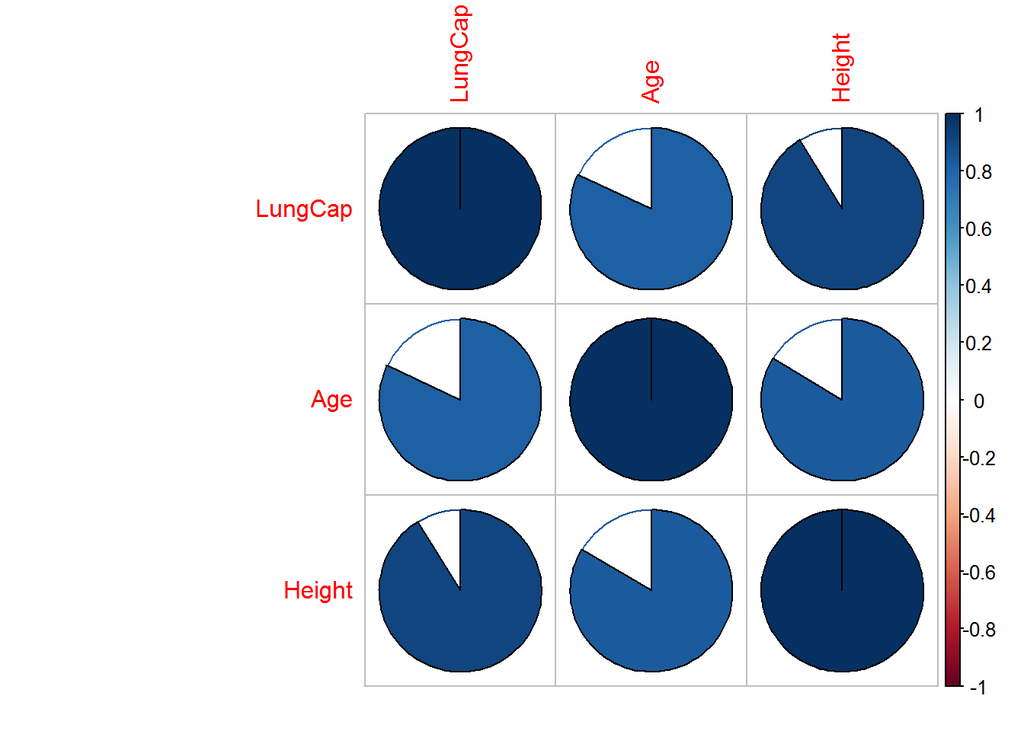

```r
library(corrplot)
corrplot(cor(LungCapData[,1:3]),method = 'pie')
```

##### *Pair plots are way to visualize relationship between each variables. It produces a matrix of relationship between each variable for an instant examination of our data.*

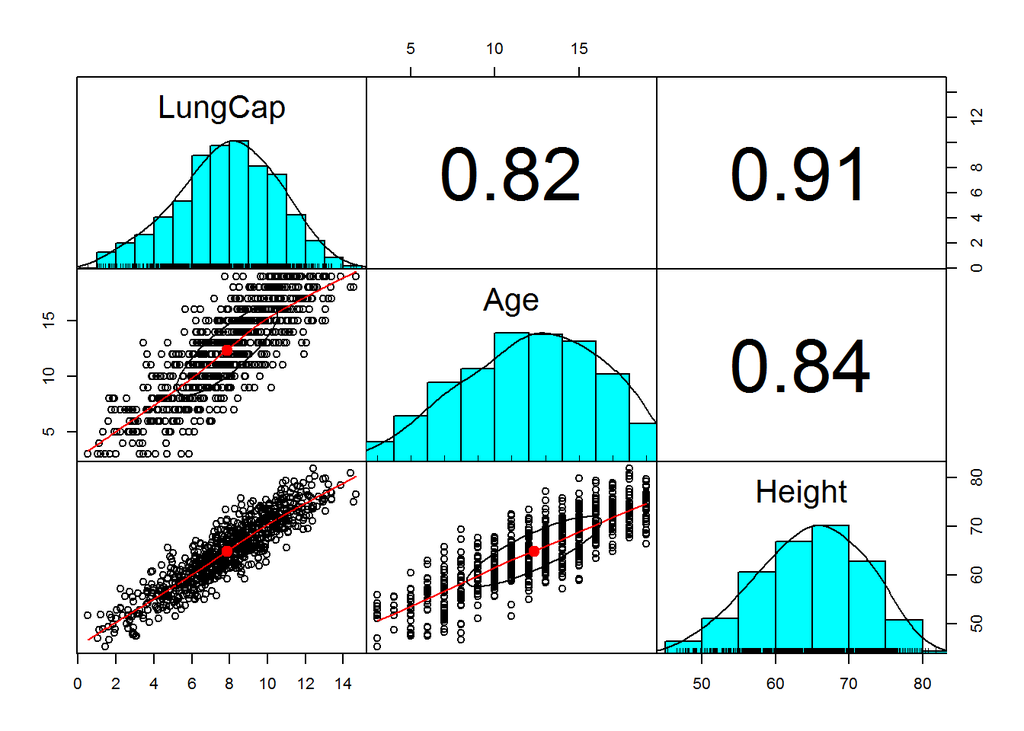

```r
library(psych)
library(ggplot2)
pairs.panels(LungCapData[c(1:3)],gap=0,bg=c("red","yellow","blue")[LungCapData$Smoke],pch=21)
```

# **Multivariate Analysis**

##### *You try to understand a sense of relationship of all variables with one another.*

```r
aggregate(data.frame("LungCap"=LungCapData$LungCap,"Age"=LungCapData$Age,"Height(cm)"=LungCapData$Height), by=list(Smoke=LungCapData$Smoke), FUN=mean)
```

```
##   Smoke  LungCap      Age Height.cm.
## 1    no 7.770188 12.03549   64.39830
## 2   yes 8.645455 14.77922   68.52208
```

# **VISUALIZATION**

#### **Histogram -***is a quick way to get information about a sample distribution without detaild statistical Analysis.*

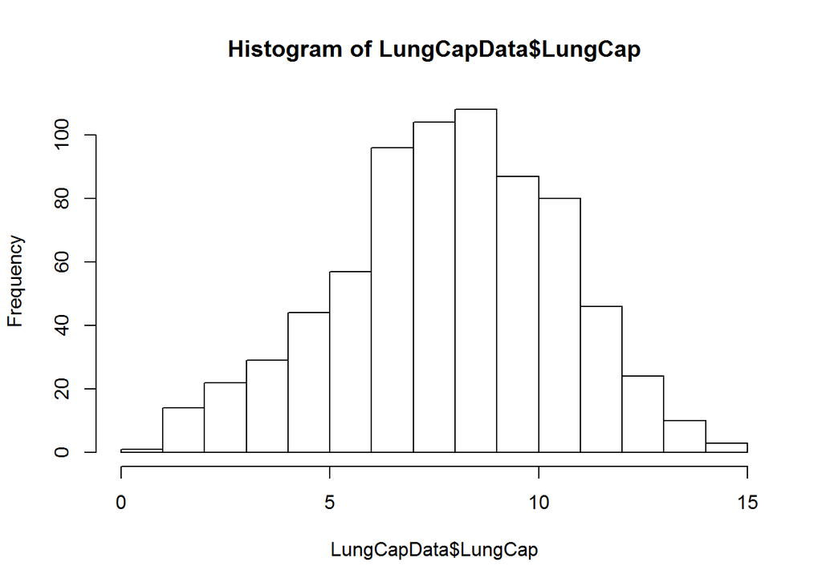

```r
hist(LungCapData$LungCap)
```

#### **Barplot**

##### *Barplot is appropriate for summarizing the distribution of a categorical variables.*

```r
count <- table(Gender); count
```

```
## Gender
## female   male
##    358    367
```

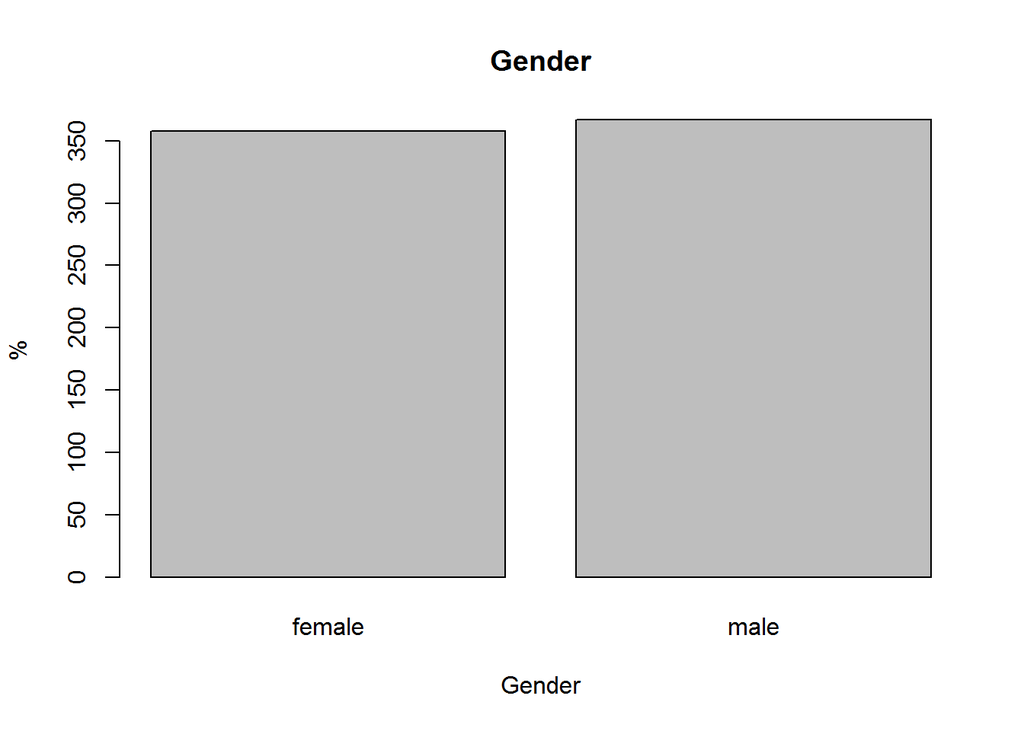

```r
barplot(count,main = "Gender",xlab = "Gender",ylab = "%")
```

```r
percentage <- table(Gender)/length(Gender)
```

##### *Adding Titles to the plot*

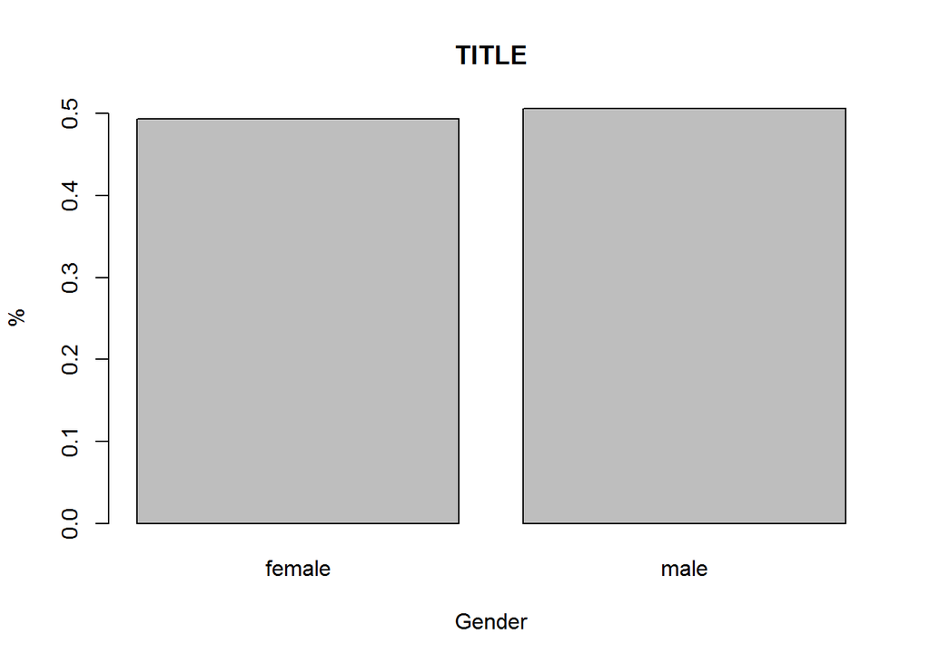

```r
barplot(percentage,main = "TITLE",xlab = "Gender",ylab = "%")
```

#### **Pie Charts**

##### *Pie chart is appropriate for summarizing the distribution of a categorical variables.*

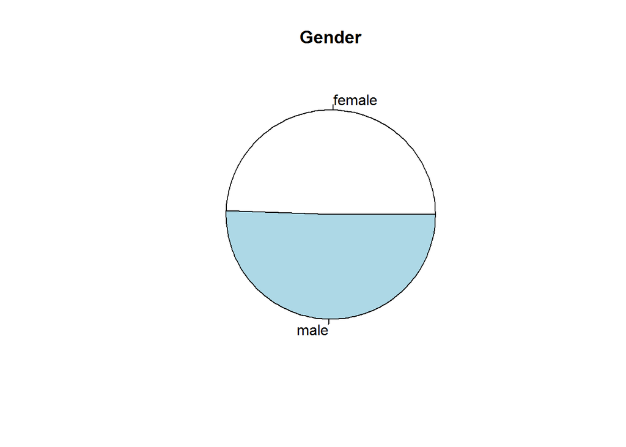

```r
pie(count, main = "Gender")
```

#### **Boxplot**

##### *Boxplot is appropriate for summarizing the distribution of a numerical variables.*

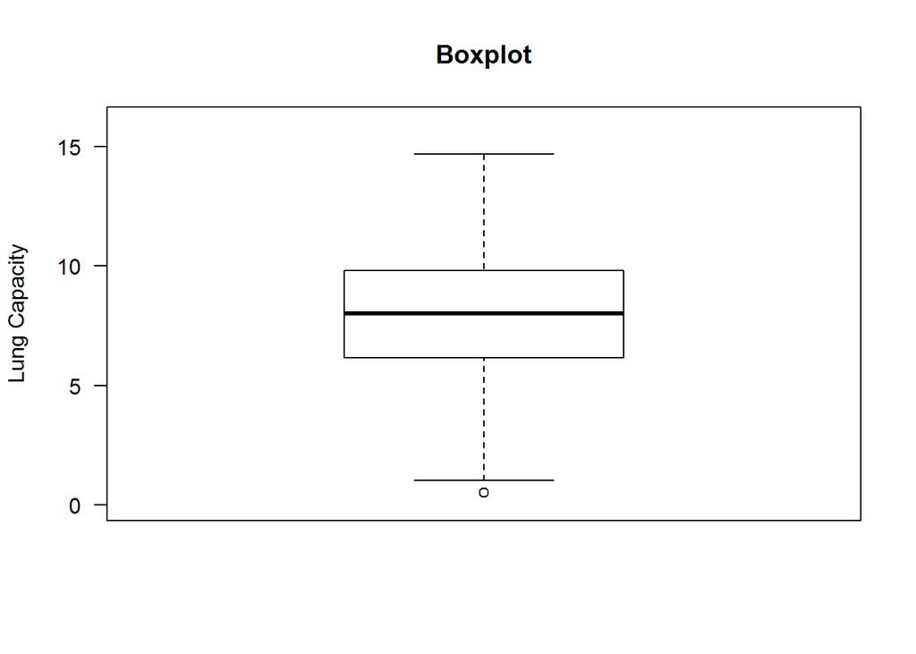

```r
boxplot(LungCap,main='Boxplot',ylab='Lung Capacity',ylim=c(0,16),las=1)
```

#### **Density plot**

##### *Density plot is appropriate for summarizing the distribution of a numerical variables.*

```r
d <- density(LungCap)
```

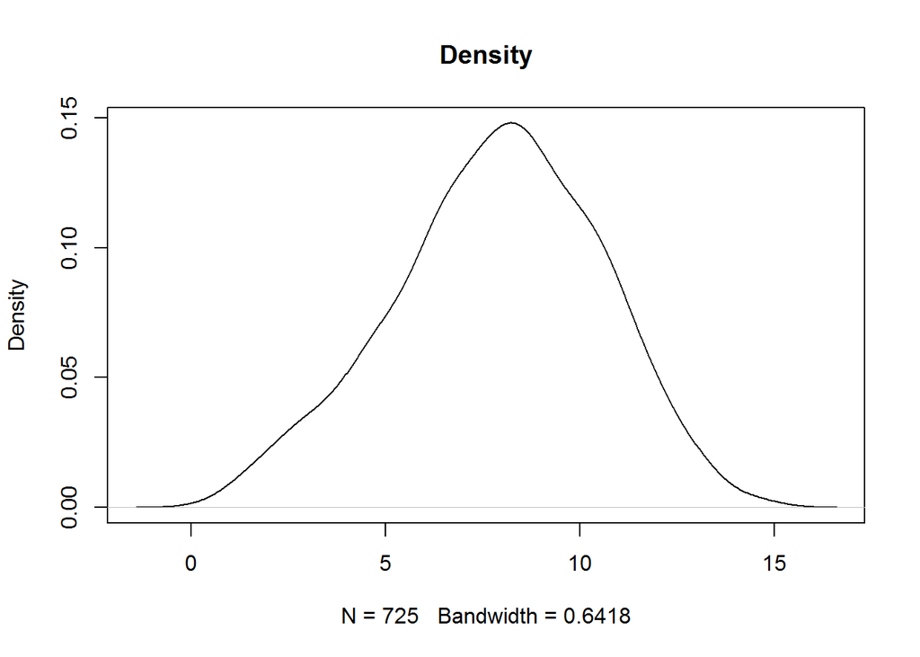

```r
plot(d, main = 'Density')
```

#### **Stratified Boxplot**

##### *is useful for examining the relationship between a categorical variable and numerica variable with strata or groupe.*

```r
AgeGroups <- cut(Age,breaks = c(0,13,15,17,25),labels = c("<13","14/15","15/17","18"))
```

```r
Age[1:5]
```

```
## [1]  6 18 16 14  5
```

```r
AgeGroups[1:5]
```

```
## [1] <13   18    15/17 14/15 <13
## Levels: <13 14/15 15/17 18
```

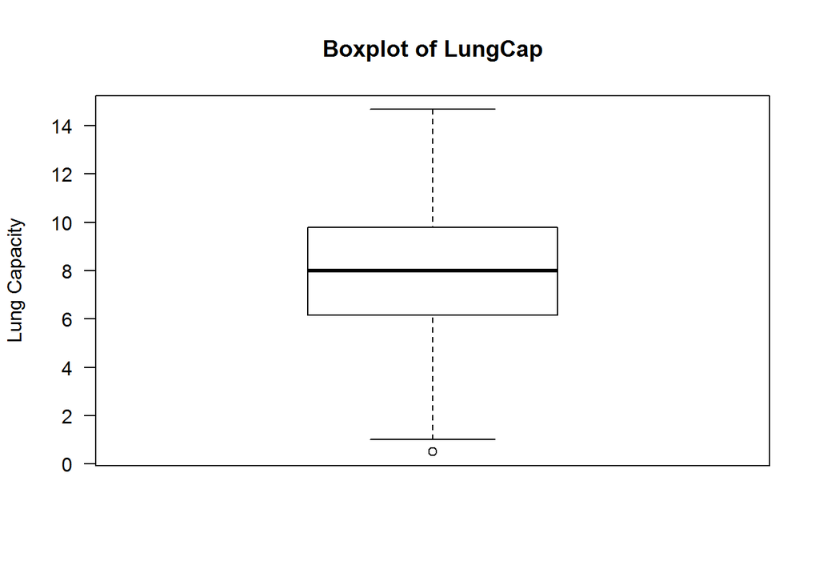

```r
boxplot(LungCap,ylab='Lung Capacity',main="Boxplot of LungCap",las = 1)
```

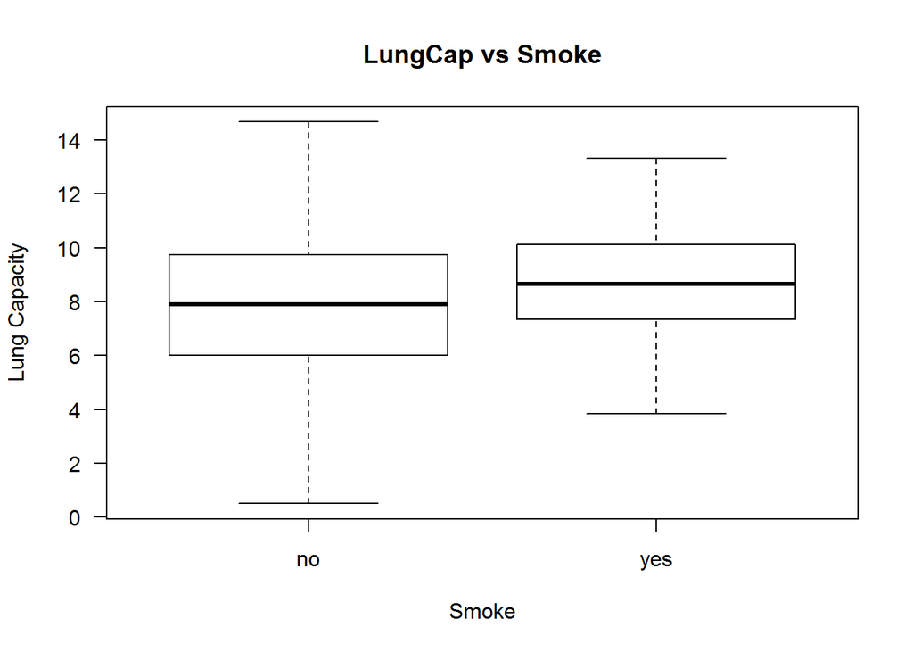

```r
boxplot(LungCap ~ Smoke,ylab = "Lung Capacity",main="LungCap vs Smoke",las = 1)
```

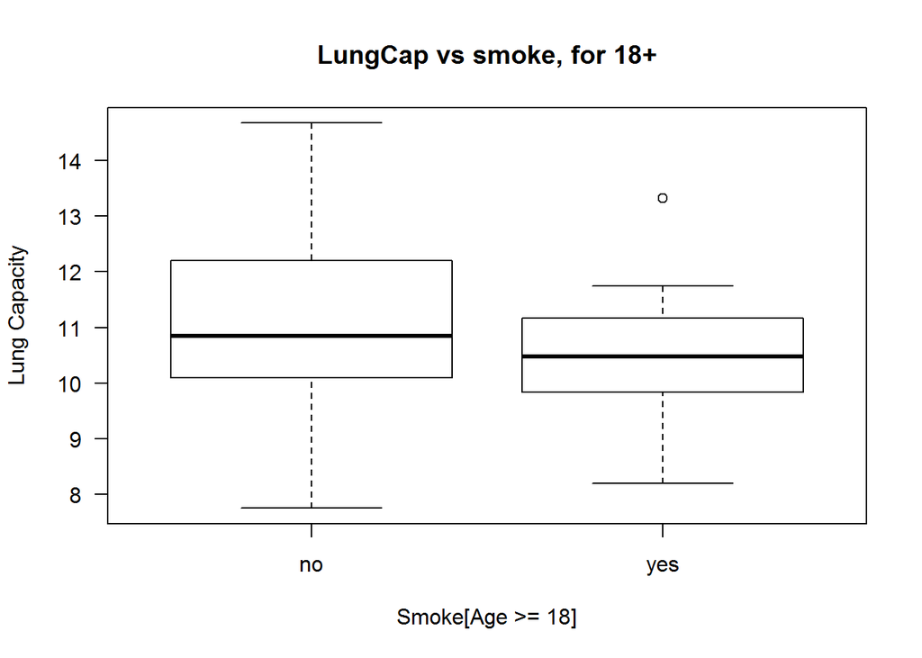

```r
boxplot(LungCap[Age >= 18] ~ Smoke[Age >= 18],ylab = "Lung Capacity",main = "LungCap vs smoke, for 18+",las=1)
```

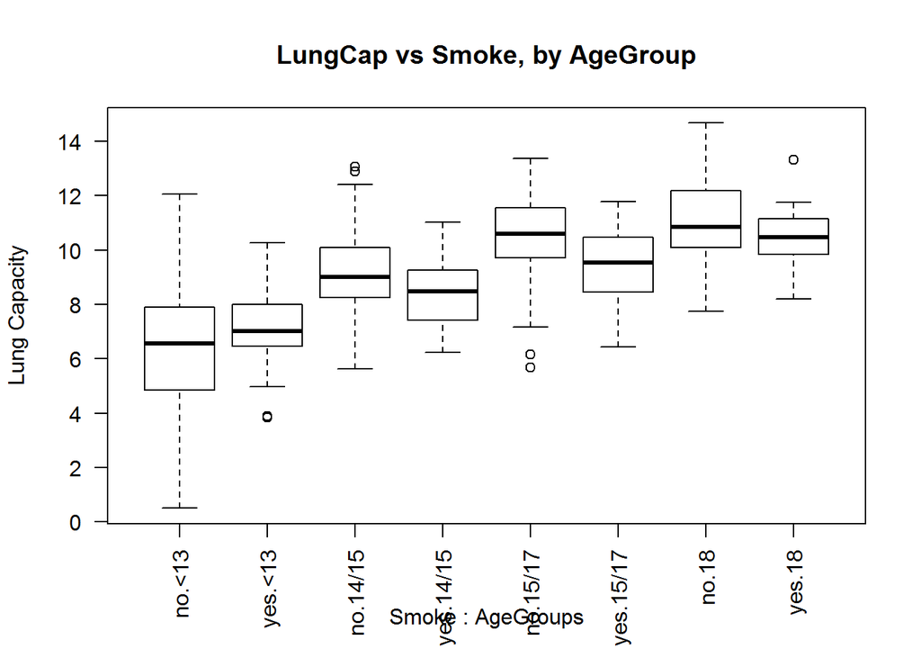

```r
boxplot(LungCap ~ Smoke * AgeGroups,ylab = "Lung Capacity", main = "LungCap vs Smoke, by AgeGroup",las = 2)
```

### **Steam and Leaf Plot**

#### *is appropriate for summarizing the distribution of a numberic variables and are most appropriate for smaller datasets.*

```r
femaleLungCap <- LungCap[Gender == "female"]
```

```r
stem(femaleLungCap,scale = 2)
```

```
##
##   The decimal point is at the |
##
##    0 | 5
##    1 | 013
##    1 | 5689
##    2 | 00334
##    2 | 56777789999
##    3 | 01224
##    3 | 57788999999
##    4 | 012333344
##    4 | 555556666677777899
##    5 | 00001222223344
##    5 | 66666777778999
##    6 | 00011111112222222223334
##    6 | 5555556666667777777788888999999
##    7 | 00012333444444444
##    7 | 5555666667778888888999999
##    8 | 000000001111122222333333444444
##    8 | 555556666666666777777888888888899
##    9 | 00000000111222233333444
##    9 | 55556666777788888999999
##   10 | 00001111122233444
##   10 | 5555666777778899
##   11 | 00111223
##   11 | 556678888
##   12 | 12224
##   12 | 79
##   13 | 1
```

### **Scatterplot**

#### *is appropriate for examining the relationship between 2 numerica variable*

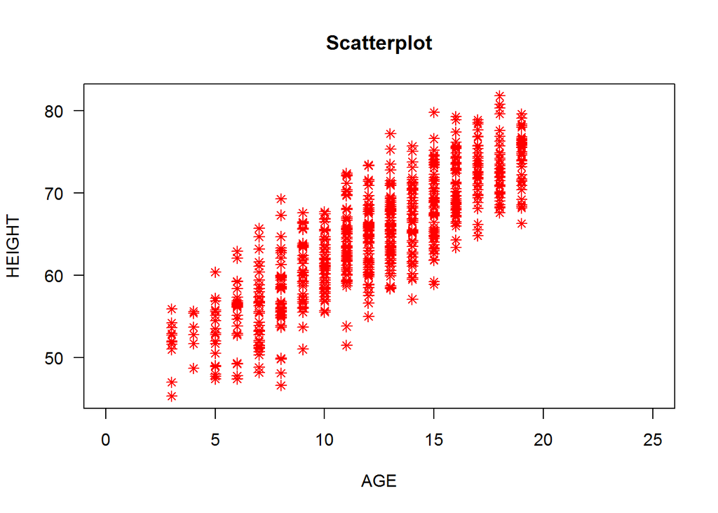

```r
plot(Age,Height,main = 'Scatterplot',xlab='AGE',ylab = 'HEIGHT',las=1,xlim = c(0,25),pch=8,col=2)
```

# **INFERENTIAL STATISTICS**

#### **Hypothesis Testing** *Parametric Test*

##### **Z-test one-sided**

```r
# H0 : Male smoker is greater than female smoker.
# CI : 95 %

t <- table(Gender,Smoke);t
```

```
##         Smoke
## Gender    no yes
##   female 314  44
##   male   334  33
```

#### *Make a Barplot to examine the distribution of data*

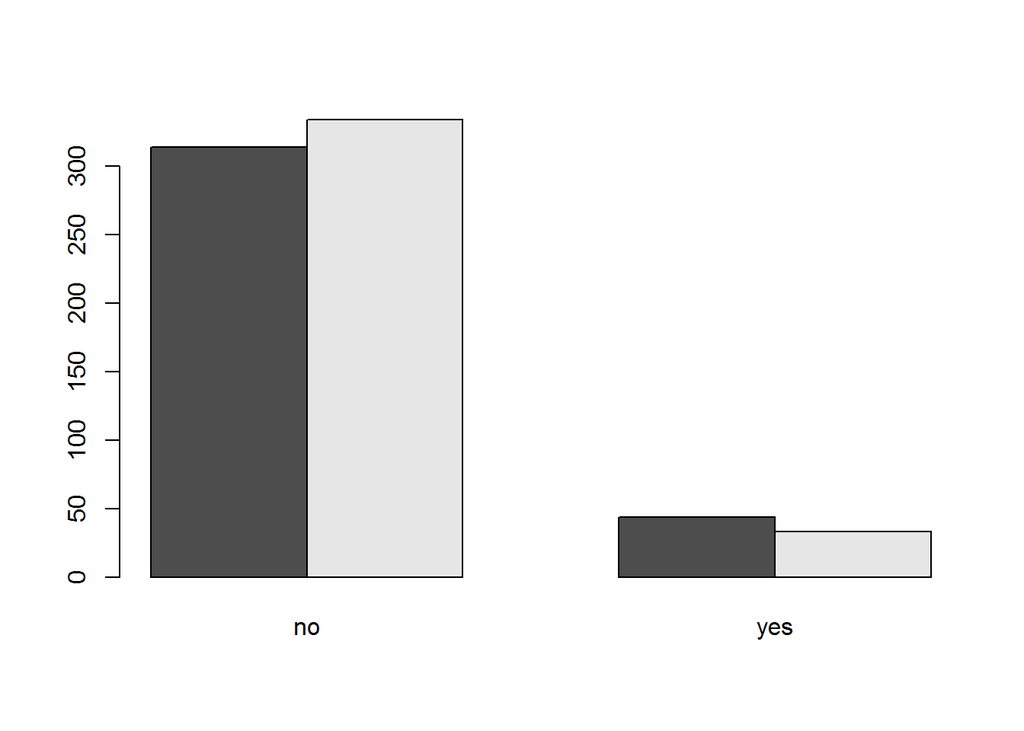

```r
barplot(t,beside = TRUE)
```

```r
prop.test(t,correct = FALSE,alternative = 'greater')
```

```
##
##  2-sample test for equality of proportions without continuity
##  correction
##
## data:  t
## X-squared = 2.0773, df = 1, p-value = 0.9252
## alternative hypothesis: greater
## 95 percent confidence interval:
##  -0.07064256  1.00000000
## sample estimates:
##    prop 1    prop 2
## 0.8770950 0.9100817
```

##### **Z-test two-sided**

```r
# H0 : female smoker is equal to male smoker
# CI : 95%

prop.test(t,correct = FALSE)
```

```
##
##  2-sample test for equality of proportions without continuity
##  correction
##
## data:  t
## X-squared = 2.0773, df = 1, p-value = 0.1495
## alternative hypothesis: two.sided
## 95 percent confidence interval:
##  -0.07785641  0.01188287
## sample estimates:
##    prop 1    prop 2
## 0.8770950 0.9100817
```

##### **T-test one-side**

```r
# H0 : mu < 8
# one sided 95% cI for mu

t.test(LungCap,mu=8,alternative = "less",conf.level = 0.95)
```

```
##
##  One Sample t-test
##
## data:  LungCap
## t = -1.3842, df = 724, p-value = 0.08336
## alternative hypothesis: true mean is less than 8
## 95 percent confidence interval:
##      -Inf 8.025974
## sample estimates:
## mean of x
##  7.863148
```

##### **t-test two-side - is parametric methods appropriate for examining the difference in means for 2 population.**

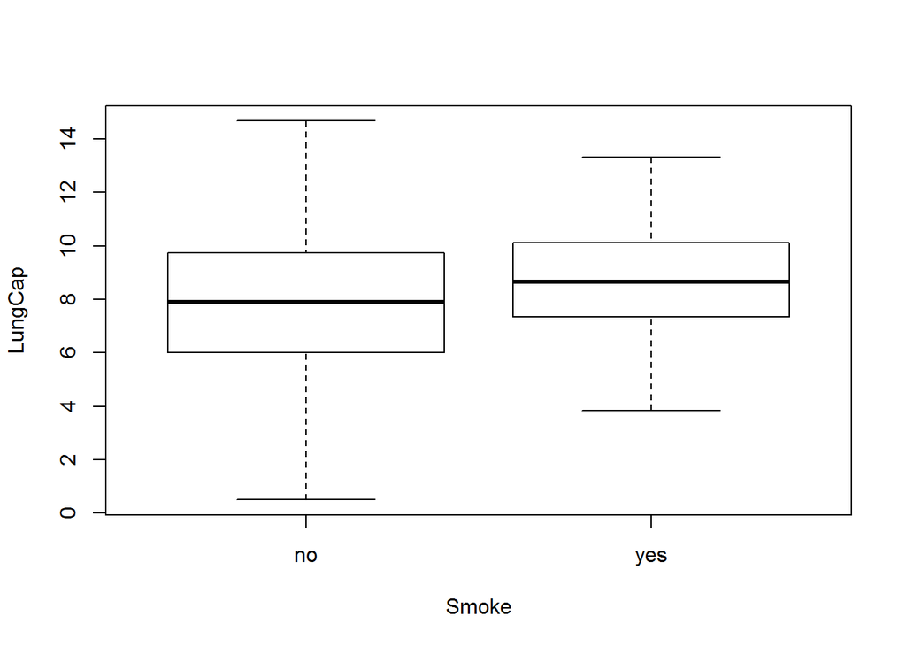

```r
boxplot(LungCap ~ Smoke)
```

```r
# Ho : mean lung cap of smokers = of non-smokers
# assume non-equal variances

t.test(LungCap ~ Smoke,mu=0,alt='two.side',conf=0.95,var.eq=F,paired =F)
```

```
##
##  Welch Two Sample t-test
##
## data:  LungCap by Smoke
## t = -3.6498, df = 117.72, p-value = 0.0003927
## alternative hypothesis: true difference in means is not equal to 0
## 95 percent confidence interval:
##  -1.3501778 -0.4003548
## sample estimates:
##  mean in group no mean in group yes
##          7.770188          8.645455
```

##### **Chi-square - Appropriate for testing independence between two categorical variables.**

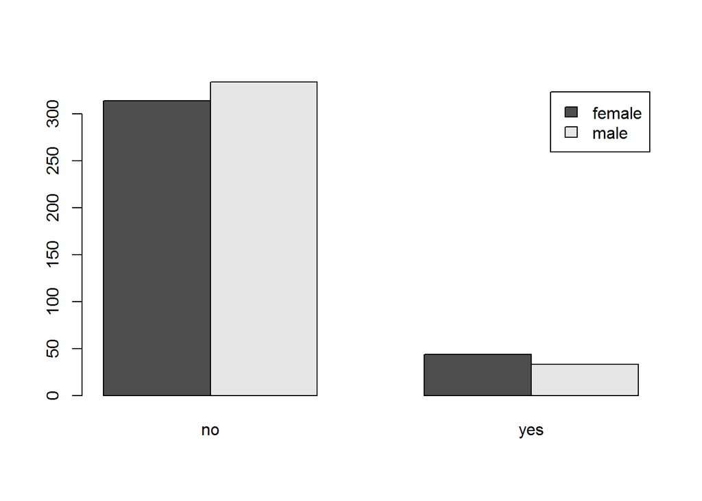

```r
# For chi-square test produce a contigency table

TAB <- table(Gender,Smoke)

# produce a barplot to check the distribution.

barplot(TAB,beside = T,legend=T)
```

```r
CHI <- chisq.test(TAB,correct = T)
CHI
```

```
##
##  Pearson's Chi-squared test with Yates' continuity correction
##
## data:  TAB
## X-squared = 1.7443, df = 1, p-value = 0.1866
```

##### **ANOVA - appropriate for comparing the means for 2 or more independent populations.**

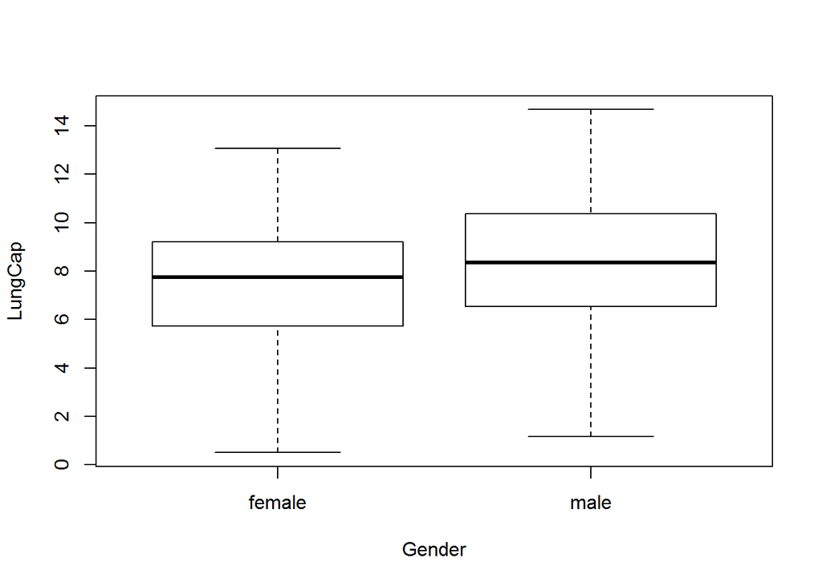

```r
# produce a box plot to check the distribution of Lung cap variable and gender variable.

boxplot(LungCap ~ Gender)
```

```r
# H0 : Mean Lungcap  is the same for all Genders

ANOVA1 <-  aov(LungCap ~ Gender)
summary(ANOVA1)
```

```
##              Df Sum Sq Mean Sq F value   Pr(>F)
## Gender        1    148  147.96   21.47 4.26e-06 ***
## Residuals   723   4983    6.89
## ---
## Signif. codes:  0 '***' 0.001 '**' 0.01 '*' 0.05 '.' 0.1 ' ' 1
```

```r
TukeyHSD(ANOVA1)
```

```
##   Tukey multiple comparisons of means
##     95% family-wise confidence level
##
## Fit: aov(formula = LungCap ~ Gender)
##
## $Gender
##                  diff       lwr      upr   p adj
## male-female 0.9035866 0.5207397 1.286434 4.3e-06
```

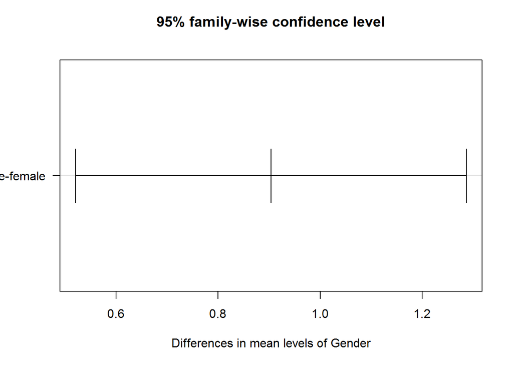

```r
plot(TukeyHSD(ANOVA1),las=1)
```

### **Non-Parametric Test**

##### **Mann-Whitney U Test A.K.A Wilcoxon Rank sum test -** *appropriate for examining the difference in Medians for 2 independent populations*

```r
# Ho : Median Lung Capacity of Smokers  = that of non smokers
# two sided test

wilcox.test(LungCap ~ Smoke,mu=0,alt='two.sided',conf.int=T,conf.level = 0.95,paired=F,exact=F,correct =T)
```

```
##
##  Wilcoxon rank sum test with continuity correction
##
## data:  LungCap by Smoke
## W = 20128, p-value = 0.005538
## alternative hypothesis: true location shift is not equal to 0
## 95 percent confidence interval:
##  -1.3999731 -0.2499419
## sample estimates:
## difference in location
##             -0.8000564
```

##### **Kruskal Wallis Test -** *equivalent to one-way Analysis of Variance*

```r
kruskal.test(LungCap ~ Gender)
```

```
##
##  Kruskal-Wallis rank sum test
##
## data:  LungCap by Gender
## Kruskal-Wallis chi-squared = 18.325, df = 1, p-value = 1.862e-05
```

##### **Fisher’s Exact test* -** *alternative to the chi-square test, it is used when the assumptions of chi-square test not met.we may consider using Fisher’s Exact Test*

```r
fisher.test(TAB,conf.int = T,conf.level = 0.99)
```

```
##
##  Fisher's Exact Test for Count Data
##
## data:  TAB
## p-value = 0.1845
## alternative hypothesis: true odds ratio is not equal to 1
## 99 percent confidence interval:
##  0.3625381 1.3521266
## sample estimates:
## odds ratio
##  0.7054345
```